# STAT 37810 HW 2

ZY Fang

10/11/2018

### This homework is based on the 2nd version of the book. And I add a complement of exercises in Section 4.4.1.

# Section 4.1.1

## Exercise 2

### (a)

Calculating ratios of successive terms in Fibonacci sequence.

```r
fib <- c(1: 32)
ratio <- c(1: 30)
fib[2] <- 1

for (i in 1: 30){
  fib[i + 2] <- fib[i] + fib[i + 1]
  ratio[i] <- fib[i + 1] / fib[i]
}

ratio
```

```
##  [1] 1.000000 2.000000 1.500000 1.666667 1.600000 1.625000 1.615385
##  [8] 1.619048 1.617647 1.618182 1.617978 1.618056 1.618026 1.618037
## [15] 1.618033 1.618034 1.618034 1.618034 1.618034 1.618034 1.618034
## [22] 1.618034 1.618034 1.618034 1.618034 1.618034 1.618034 1.618034
## [29] 1.618034 1.618034
```

The sequence seems to be converging to 1.618034.

### (b)

```r
(1 + sqrt(5)) / 2
```

```
## [1] 1.618034
```

The sequence does converge to this ratio.

*Proof*

For Fibonacci sequence, we have $f_{n+2}=f_{n+1}+f_n$.

Thus $f_{n+2}+\frac{\sqrt5-1}{2}f_{n+1}=\frac{\sqrt5+1}{2}f_{n+1} + f_n=\frac{\sqrt5+1}{2}(f_{n+1}+\frac{\sqrt5-1}{2}f_n)$.

We know $f_1=f_2=1$, thus $f_2+\frac{\sqrt5-1}{2}f_1=\frac{\sqrt5+1}{2}$. Thus

$$\begin{equation}
f_{n+1}+\frac{\sqrt5-1}{2}f_n=(\frac{\sqrt5+1}{2})^n.
\tag{1}\end{equation}$$

Similarly we have $f_{n+2}+\frac{-1-\sqrt5}{2}f_{n+1}=\frac{1-\sqrt5}{2}f_{n+1} + f_n=\frac{1-\sqrt5}{2}(f_{n+1}+\frac{-1-\sqrt5}{2}f_n)$, and $f_2+\frac{-1-\sqrt5}{2}f_1=\frac{1-\sqrt5}{2}$.

Therefore
$$\begin{equation}
f_{n+1}+\frac{-1-\sqrt5}{2}f_n=(\frac{1-\sqrt5}{2})^n.
\tag{2}\end{equation}$$

Combine equation (1) and (2), we have $f_n=\frac{(\frac{\sqrt5+1}{2})^n-(\frac{1-\sqrt5}{2})^n}{\sqrt5}$, which yields
$$\lim_{n\to\infty}\frac{f_{n+1}}{f_n}=\frac{\sqrt5+1}{2}.$$

This completes the proof.

## Exercise 3

Test results of different code.

### (a)

```r
answer <- 0
for (j in 1: 5) answer <- answer + j
answer
```

```
## [1] 15
```

### (b)

```r
answer <- NULL
for (j in 1: 5) answer <- c(answer, j)
answer
```

```
## [1] 1 2 3 4 5
```

### (c)

```r
answer <- 0
for (j in 1: 5) answer <- c(answer, j)
answer
```

```
## [1] 0 1 2 3 4 5
```

### (d)

```r
answer <- 1
for (j in 1: 5) answer <- answer * j
answer
```

```
## [1] 120
```

### (e)

```r
answer <- 3
for (j in 1: 5) answer <- c(answer, (7 * answer[j]) %% 31)
answer
```

```
## [1]  3 21 23  6 11 15
```

# Section 4.1.2

## Exercise 4

```r
calcInterestGIC <- function(G, years){
  if (years <= 3)
    return (G * ((1 + 0.04) ^ years - 1))
  else
    return (G * ((1 + 0.05) ^ years - 1))
}
```

## Exercise 5

```r
calcReturnMortgage <- function(n, P, open){
  if (open) i = 0.005
  else      i = 0.0004

  return (P * i / (1 - (1 + i) ^ (-n)))
}
```

# Section 4.1.3

## Exercise 2

Generate Fibonicci sequence using *Fibonacci* variable only.

```r
Fib1 <- 1
Fib2 <- 1
Fibonacci <- c(Fib1, Fib2)

while(Fibonacci[length(Fibonacci)] < 300){
  Fibonacci <- c(Fibonacci, sum(Fibonacci[(length(Fibonacci) - 1): length(Fibonacci)]))
}
Fibonacci
```

```
##  [1]   1   1   2   3   5   8  13  21  34  55  89 144 233 377
```

## Exercise 4

Rewrite interest rate calculation by *while()* loop.

```r
calcInterestRate <- function(i){
  record <- -1;
  eps <- 1e-6

  while (abs(record - i) > eps){
    record <- i
    i <- (1 - (1 + i) ^ (-20)) / 19
  }

  return(i)
}


calcInterestRate(0.006)
```

```
## [1] 0.004954139
```

Try other starting guess:

```r
for (i in -3: 3)
  print(calcInterestRate(10 ^ i))
```

```
## [1] 0.004917156
## [1] 0.004954119
## [1] 0.004953499
## [1] 0.004953779
## [1] 0.004953779
## [1] 0.004953779
## [1] 0.004953779
```

No significant difference.

## Exercise 5

Calculate interest rate and count the number of iterations.

```r
calcInterestRate <- function(i){
  record <- -1;
  eps <- 1e-6
  iteration <- 0;

  while (abs(record - i) > eps){
    record <- i
    i <- (1 - (1 + i) ^ (-20)) / 19
    iteration <- iteration + 1
  }

  return(c(i, iteration))
}

calcResult <- calcInterestRate(0.006)
sprintf("Result: %f, iterations: %d", calcResult[1], calcResult[2])
```

```
## [1] "Result: 0.004954, iterations: 74"
```

Try other starting guess:

```r
for (i in -3: 3){
  calcResult <- calcInterestRate(10 ^ i)
  cat(sprintf("Start from %f, result: %f, iterations: %d", 10 ^ i, calcResult[1], calcResult[2]), sep = '\n')
}
```

```
## Start from 0.001000, result: 0.004917, iterations: 134
## Start from 0.010000, result: 0.004954, iterations: 94
## Start from 0.100000, result: 0.004953, iterations: 106
## Start from 1.000000, result: 0.004954, iterations: 106
## Start from 10.000000, result: 0.004954, iterations: 106
## Start from 100.000000, result: 0.004954, iterations: 106
## Start from 1000.000000, result: 0.004954, iterations: 106
```

Different starting guess needs different number of iterations.

# Section 4.1.5

## Exercise 2

### (a)

Implement the sieve of Eratosthenes using a *while()* loop.

```r
Eratosthenes <- function(n) {
  # Print prime numbers up to n
  if (n >= 2) {
    sieve <- seq(2, n)
    primes <- c()
    while (length(sieve) > 0) {
      p <- sieve[1]
      primes <- c(primes, p)
      # After pushing back the minimal prime number
      sieve = sieve[(sieve %% p) != 0]
      # remove all numbers which can be divided by this prime number
    }
    return(primes)
  } else {
    stop("Input value of n should be at least 2")
  }
}
```

### (b)

Once p >= sqrt(n), all remaining entries in *sieve* are prime.

All remaining entries in *sieve* can not be divided by prime numbers less than $\sqrt{n}$, or it will be removed from *sieve*. Thus if a remaining entry is not prime, it has at least 2 prime factors that is larger than $\sqrt{n}$, so the entry must be larger than n, which results in contradiction. That proofs all remaining entries in *sieve* are prime.

### (c)

To take advantage of the result in (b), we add a few sentences in the *while()* loop.

```r
Eratosthenes <- function(n) {
  # Print prime numbers up to n
  if (n >= 2) {
    sieve <- seq(2, n)
    primes <- c()
    while (length(sieve) > 0) {
      p <- sieve[1]
      primes <- c(primes, p)
      # After pushing back the minimal prime number
      sieve = sieve[(sieve %% p) != 0]
      # Remove all numbers which can be divided by this prime number

      # If p >= sqrt(n), all remaining entries in sieve is prime
      # Do not need further elimination, add all entries in sieve to prime
      if (p >= sqrt(n)){
        primes = c(primes, sieve);
        break
      }
    }
    return(primes)
  } else {
    stop("Input value of n should be at least 2")
  }
}
```

# Section 4.2.1

## Exercise 2

### (a)

Write a function to compute the amount of money.

```r
compound.interest <- function(P, n, i.r) {
  return (P * (1 + i.r) ^ n);
}
```

### (b)

Application in a real case, where Mr.Ng deposits $1000, interest rate is 1% per month, and period is 30 months.

```r
compound.interest(1000, 30, 0.01)
```

```
## [1] 1347.849
```

## Exercise 3

Bisection algorithm to calculate the zero of a user-supplied function *f* on a given interval $[a, b]$. It should guarantee that $f(a)f(b)\leq0$. The maximum of numerical error is given as *epsilon*.

```r
find_zero <- function(f, a, b, epsilon) {
  m = (b + a) / 2
  if (b - a < epsilon || abs(m) < 1e-9)
    return (m)

  if (f(a) * f(m) < 0)
    return (find_zero(f, a, m, epsilon))
  else
    return (find_zero(f, m, b, epsilon))

  if (abs(f(a)) < 1e-9)
    return (a)
  if (abs(f(b)) < 1e-9)
    return (b)
}

# test case: function y = x - 1 on interval [-1, 2], epsilon = 1e-9
find_zero(function(x) x - 1, -1, 2, 1e-9)
```

```
## [1] 1
```

# Section 4.4.1

## Exercise 1

Write a **Mergesort()** function, which allows sorting in decreasing order.

The code in the textbook has some bugs. I fix them and add some comment in related lines.

```r
mergesort <- function(x, decreasing) {
  len <- length(x)
  if (len < 2) result <- x
  else {
    y <- x[1: floor(len / 2)]
    z <- x[floor(len / 2 + 1): len]
    ## floor() is necessary, or it may cause trouble.
    ## There is no floor() in the code in the textbook.

    y <- mergesort(y, decreasing)
    z <- mergesort(z, decreasing)

    result <- c()

    while (min(length(y), length(z)) > 0) {
      if (decreasing) {
        if (y[1] > z[1]) {
          result <- c(result, y[1])
          y <- y[-1]

          ## These lines seem really slow, causing the time complexity to be O(N^2logN)
          ## But they are in the textbook, so I just copy them
        }
        else {
          result <- c(result, z[1])
          z <- z[-1]
        }
      }
      else {
        if (y[1] < z[1]) {
          result <- c(result, y[1])
          y <- y[-1]
        }
        else {
          result <- c(result, z[1])
          z <- z[-1]
        }
      }
    }

    if (length(y) > 0) result <- c(result, y)
    if (length(z) > 0) result <- c(result, z)
  }

  return (result)
}

## test
mergesort(c(1,4,2,8,5,7), TRUE)
```

```
## [1] 8 7 5 4 2 1
```

```r
mergesort(c(1,4,2,8,5,7), FALSE)
```

```
## [1] 1 2 4 5 7 8
```

## Exercise 2

Newton’s method.

### (a)

```r
Newton <- function(f, g, fx, fy, gx, gy, epsilon, x0, y0) {
  old_x <- 99999
  old_y <- 99999

  while ((abs(old_x - x0) > epsilon) || (abs(old_y - y0) > epsilon)) {
    old_x <- x0
    old_y <- y0

    fxn <- fx(old_x, old_y)
    fyn <- fy(old_x, old_y)
    gxn <- gx(old_x, old_y)
    gyn <- gy(old_x, old_y)
    fn <- f(old_x, old_y)
    gn <- g(old_x, old_y)
    dn <- fxn * gyn - fyn * gxn

    x0 <- old_x - (gyn * fn - fyn * gn) / dn
    y0 <- old_y - (fxn * gn - gxn * fn) / dn
  }

  return (c(x0, y0))
}
```

### (b)

Test *Newton()*.

```r
f <- function(x, y) (x + y)
g <- function(x, y) (x ^ 2 + 2 * y ^ 2 - 2)
fx <- function(x, y) (1)
fy <- function(x, y) (1)
gx <- function(x, y) (2 * x)
gy <- function(x, y) (4 * y)

## starting point x = 2, y = 2
Newton(f, g, fx, fy, gx, gy, 1e-7, 2, 2)
```

```
## [1] -0.8164966  0.8164966
```

# Section 4.4

## Exercise 1

Compute factorial.

```r
factorial <- function(n) {
  return (prod(1: n))
}

factorial(10)
```

```
## [1] 3628800
```

```r
factorial(50)
```

```
## [1] 3.041409e+64
```

```r
factorial(100)
```

```
## [1] 9.332622e+157
```

```r
factorial(1000)
```

```
## [1] Inf
```

The result is not precise when n gets larger. It also causes the product to be *Inf* when n is really large. Obviously we are not satisfied about such result.

High-precision product.

```r
# bigInt is a class that each digit is reserved and restored in a list
# e.g. bigInt(321) = c(1, 2, 3)

print.bigInteger <- function(bigInt) {
  len <- length(bigInt)
  result <- ''

  for (i in 1: len)
    result <- paste(result, bigInt[len + 1 - i], sep = '')

  cat(result)
  invisible(bigInt)
}

factorial.bigInteger <- function(n) {
  ans.bigInt <- c(1)
  for (i in 1: n) {
    ans.bigInt <- ans.bigInt * i
    up <- 0;
    for (j in 1: length(ans.bigInt)){
      ans.bigInt[j] <- ans.bigInt[j] + up
      up <- floor(ans.bigInt[j] / 10)
      ans.bigInt[j] <- ans.bigInt[j] - up * 10
    }
    while (up > 0){
      ans.bigInt <- c(ans.bigInt, up %% 10)
      up <- floor(up / 10)
    }
  }
  class(ans.bigInt) <- "bigInteger"

  return (ans.bigInt)
}

factorial.bigInteger(10)
```

```
## 3628800
```

```r
factorial.bigInteger(50)
```

```
## 30414093201713378043612608166064768844377641568960512000000000000
```

```r
factorial.bigInteger(100)
```

```
## 93326215443944152681699238856266700490715968264381621468592963895217599993229915608941463976156518286253697920827223758251185210916864000000000000000000000000
```

```r
factorial.bigInteger(1000)
```

[output not shown]

## Exercise 2

### (a)

Compute the binomial coefficient.

```r
binomialCoef <- function(n, m) {
  return (factorial(n) / factorial(m) / factorial(n - m))
}
```

### (b)

```r
binomialCoef(4, 2)
```

```
## [1] 6
```

```r
binomialCoef(50, 20)
```

```
## [1] 4.712921e+13
```

```r
binomialCoef(5000, 2000)
```

```
## [1] NaN
```

### (c)

Improve binomial coefficient computing.

```r
improvedBinomialCoef <- function(n, m) {
  numExp = sum(log((m + 1): n)) - sum(log(1: (n - m)))
  if (exp(numExp) < Inf)
    return (exp(numExp))
  else
    return (paste('e ^', as.character(numExp)))
}
```

### (d)

```r
improvedBinomialCoef(4, 2)
```

```
## [1] 6
```

```r
improvedBinomialCoef(50, 20)
```

```
## [1] 4.712921e+13
```

```r
improvedBinomialCoef(5000, 2000)
```

```
## [1] "e ^ 3360.59430531741"
```

# Chapter 4

## Exercise 1

RANDU striking pattern.

It takes a very long time to generate the pictures. I generated the pictures in the old version, which you may find in Github. Here I reduce the number of total samples to only 300000 to form a simplified version.

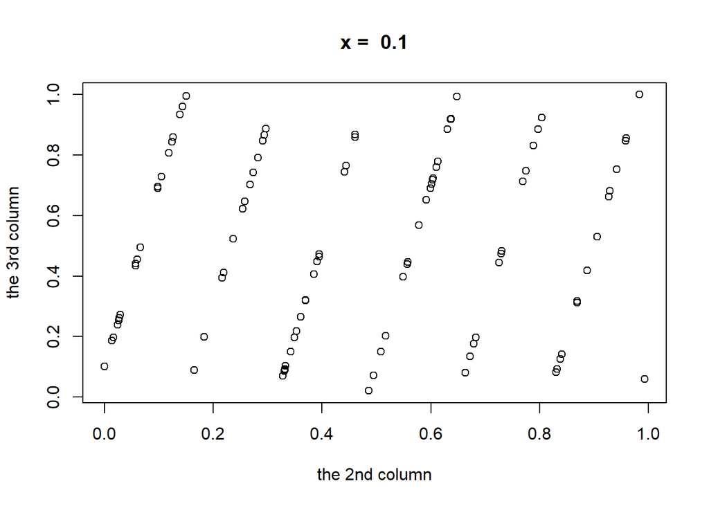

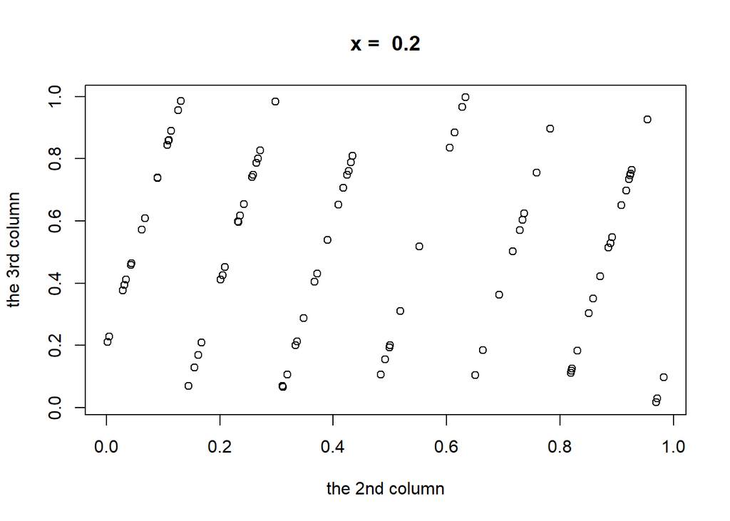

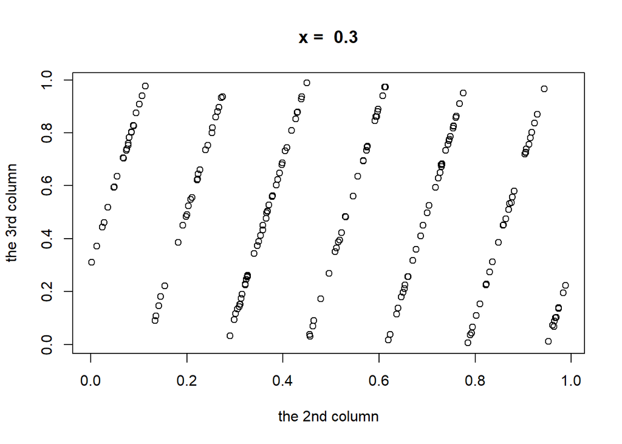

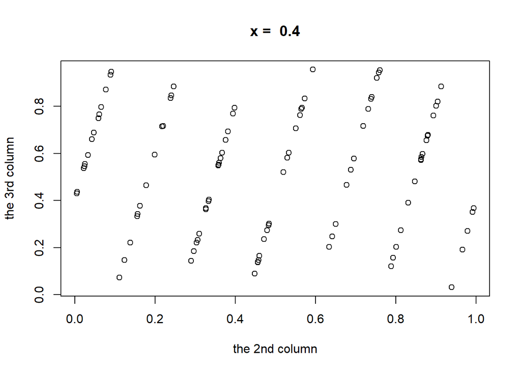

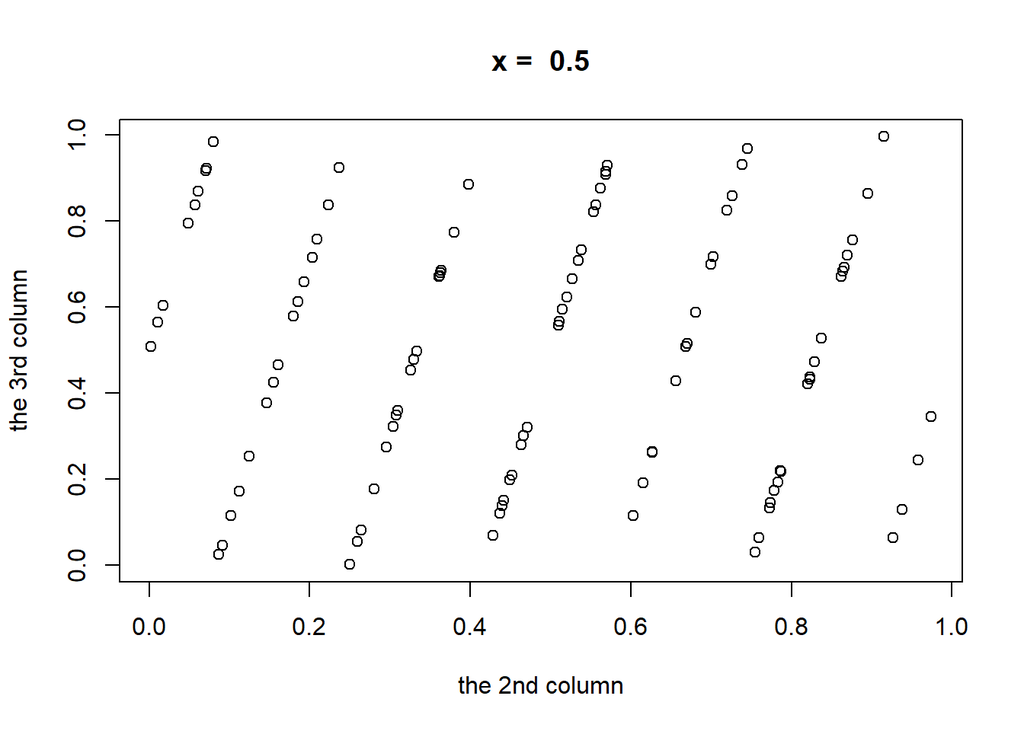

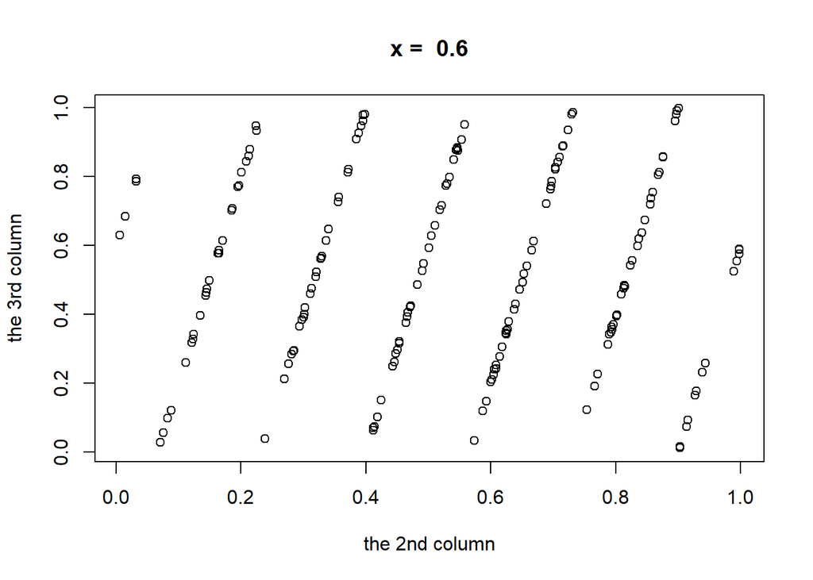

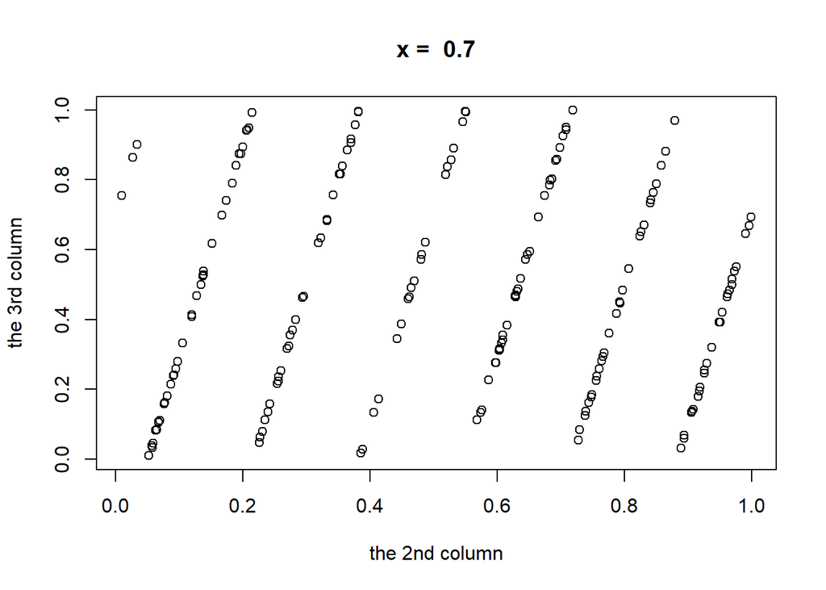

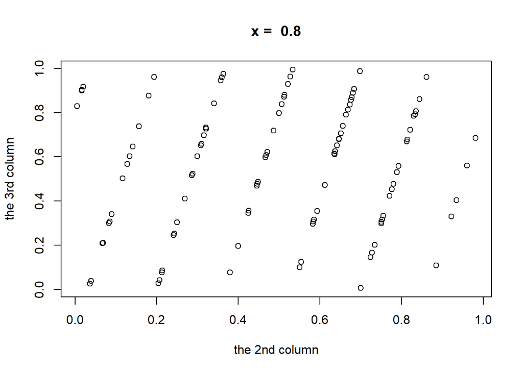

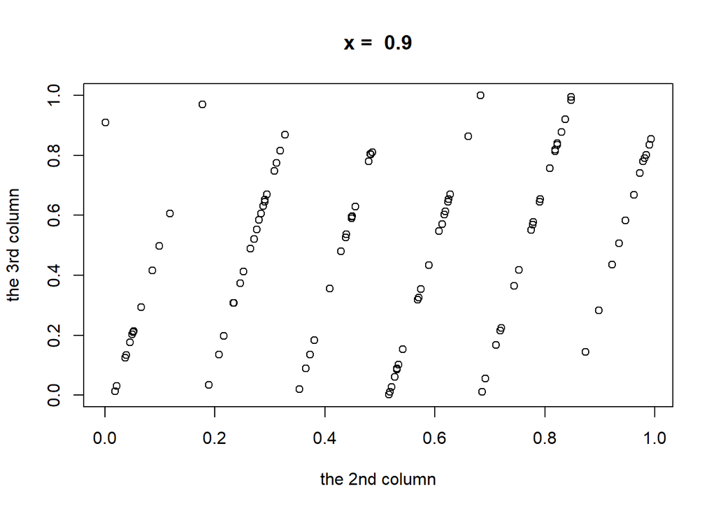

```r
Randu <- function(N, x) {
  lst <- c(1: N)
  for (i in 1: N) {
    x <- (x * 65539) %% (2 ^ 31)
    lst[i] <- round(x / (2 ^ 31), digits = 3)
  }

  return (lst)
}

len = 300000

myList <- Randu(len, 142857)
row1 <- c()
row2 <- c()
row3 <- c()
for (i in 1: len) {
  if (i %% 3 == 1) row1 <- c(row1, myList[i])
  if (i %% 3 == 2) row2 <- c(row2, myList[i])
  if (i %% 3 == 0) row3 <- c(row3, myList[i])
}

for (j in 1: 9) {
  x <- j * 0.1
  record2 <- c(1: 100000)
  record3 <- c(1: 100000)
  iter <- 0

  for(i in 1: (len / 3)) {
    if (abs(x - row1[i]) < 1e-3) {
      iter <- iter + 1
      record2[iter] <- row2[i]
      record3[iter] <- row3[i]
    }
  }
  if(iter > 0) {
    plot(record2[1: iter], record3[1: iter], main = paste("x = ", as.character(x)), xlab = "the 2nd column", ylab = "the 3rd column")
  }
}
```

## Exercise 2

Evaluate polynomials. Vector *P* contains the polynomial coefficients, i.e.$P[i]=c_{n+1-i}$.

```r
directpoly <- function(P, x) {
  ans <- 0
  for (i in 1: length(P))
    ans <- ans + P[i] * x ^ (i - 1)

  return (ans)
}

#test this function
P <- c(1, 2, 1)
# y = x^2 + 2x + 1
x <- 1
directpoly(P, x)
```

```
## [1] 4
```

## Exercise 3

```r
hornerpoly <- function(P, x) {
  ans <- c()
  for (x_value in x) {
      a <- P[1]
      for (i in 2: length(P))
        a <- a * x_value + P[i]

      ans <- c(ans, a)
  }
  return (ans)
}

#test this function
P <- c(1, 2, 1)
# y = x^2 + 2x + 1
x <- c(-2, -1, 0, 1, 2)
hornerpoly(P, x)
```

```
## [1] 1 0 1 4 9
```